# Yelp Restaurant Reviews Analysis

Sadie O'Connor, Joe Hancock, Alex White

The purpose of this analysis is to understand the sentiment of various restaurant reviews in this dataset, analyze topics and perform sentiment analysis around specific topics, and predict the number of stars that a rating will give a restaurant.

*Disclosure: AI was used to fix bugs and generate some code to make sure we were able to answer the relevant questions we posed in our initial proposal.*

### Install Packages

```python
from google.colab import drive
drive.mount('/content/drive')
```

```python
#install the needed packages
!pip install -q gensim # topic modelling
!pip install -q pyLDAvis # LDA visualization
!pip install -q nltk
```

```python
!pip install vaderSentiment gensim wordcloud

import pandas as pd
import numpy as np
import matplotlib.pyplot as plt
import re
import nltk
from nltk.corpus import stopwords
from wordcloud import WordCloud
from gensim import corpora
from gensim.models import LdaModel
from gensim.models import CoherenceModel
from gensim.models.phrases import Phrases, Phraser
from gensim.utils import simple_preprocess
from vaderSentiment.vaderSentiment import SentimentIntensityAnalyzer
from collections import Counter
from sklearn.feature_extraction.text import CountVectorizer, TfidfVectorizer
from sklearn.naive_bayes import BernoulliNB, MultinomialNB
from sklearn import metrics
from sklearn.model_selection import train_test_split
from scipy.sparse import hstack, csr_matrix
import time

nltk.download('stopwords')
stop_words = set(stopwords.words('english'))
```

### Import Data & Initial Analysis

```python
from datasets import load_dataset

ds = load_dataset("shreyahavaldar/restaurant_reviews_unprocessed")

# Convert to DataFrame
split = list(ds.keys())[0]
df = ds[split].to_pandas()

print("Shape:", df.shape)
print("\nColumns:", df.columns.tolist())
print("\nLabel Distribution:")
print(df['label'].value_counts().sort_index())
print("\nNull Counts:")
print(df.isnull().sum())
print("\nSample Rows:")
df.head()
```

```
Shape: (1000, 3)

Columns: ['review_id', 'label', 'text']

Label Distribution:
label
1    167
2    164
3    320
4    171
5    178
Name: count, dtype: int64

Null Counts:
review_id    0
label        0
text         0
dtype: int64

Sample Rows:
```

|  | review_id | label | text |
| --- | --- | --- | --- |
| 0 | 1 | 5 | <p>The pasta was tasty and the waiter was pr... |
| 1 | 2 | 5 | \n<b>The salad was juicy and the host was ... |
| 2 | 3 | 1 | \n<p>The dumplings was greasy and the servi... |
| 3 | 4 | 5 | \n<p>The pizza was fresh and the host was q... |
| 4 | 5 | 1 | <b>The pizza was stale and the host was unhel... |

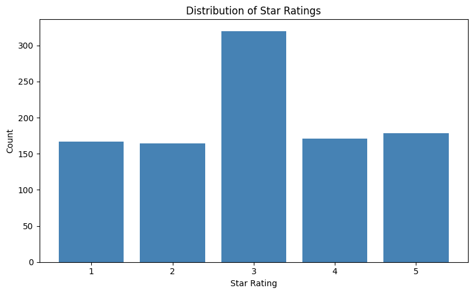

```
label
1    167
2    164
3    320
4    171
5    178
Name: count, dtype: int64
```

```python
label_counts = df['label'].value_counts().sort_index()

plt.figure(figsize=(8, 5))
plt.bar(label_counts.index.astype(str), label_counts.values, color='steelblue')
plt.title("Distribution of Star Ratings")
plt.xlabel("Star Rating")
plt.ylabel("Count")
plt.tight_layout()
plt.show()

print(label_counts)
```

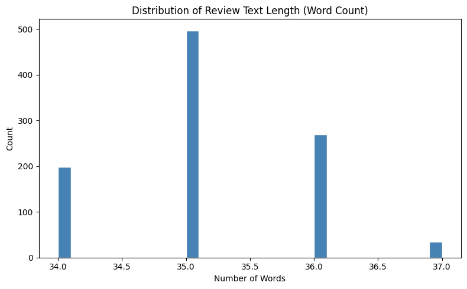

```
count    1000.000000
mean       35.140000
std         0.767456
min        34.000000
25%        35.000000
50%        35.000000
75%        36.000000
max        37.000000
Name: text_length, dtype: float64
```

```python
df['text_length'] = df['text'].apply(lambda x: len(str(x).split()))

plt.figure(figsize=(8, 5))
plt.hist(df['text_length'], bins=30, color='steelblue', edgecolor='white')
plt.title("Distribution of Review Text Length (Word Count)")
plt.xlabel("Number of Words")
plt.ylabel("Count")
plt.tight_layout()
plt.show()

print(df['text_length'].describe())
```

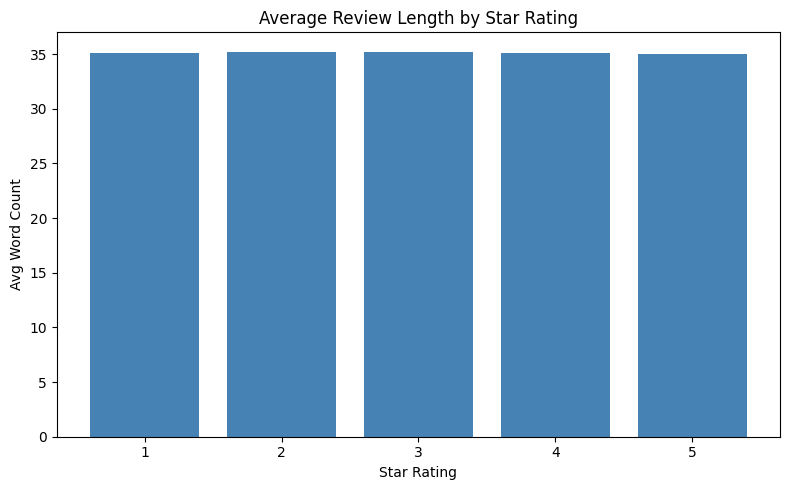

```
label
1    35.131737
2    35.189024
3    35.228125
4    35.081871
5    35.000000
Name: text_length, dtype: float64
```

```python
avg_len = df.groupby('label')['text_length'].mean()

plt.figure(figsize=(8, 5))
plt.bar(avg_len.index.astype(str), avg_len.values, color='steelblue')
plt.title("Average Review Length by Star Rating")
plt.xlabel("Star Rating")
plt.ylabel("Avg Word Count")
plt.tight_layout()
plt.show()

print(avg_len)
```

Initial findings:

From the analysis of average star rating, number of words per review, and average length per star rating, we found that the average rating was 3, with around 35 words in most reviews. There were also some larger and smaller. In the distribution of ratings by average length, the average was across all 5 star ratings. This is likley since 35 ish words makes up the majority of reviews, but also that this is a synthetic dataset meant to replicate real web scraped reviews, so some are likley auto generated at the same length.

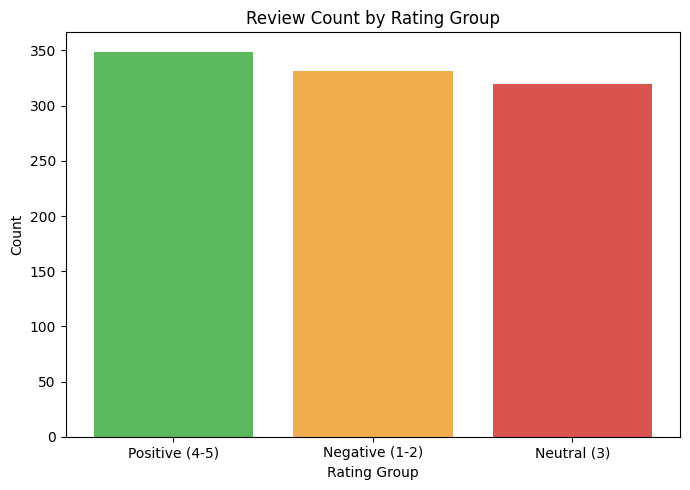

```
rating_group
Positive (4-5)    349
Negative (1-2)    331
Neutral (3)       320
Name: count, dtype: int64
```

```python
df['rating_group'] = df['label'].map({
    1: 'Negative (1-2)', 2: 'Negative (1-2)',
    3: 'Neutral (3)',
    4: 'Positive (4-5)', 5: 'Positive (4-5)'
})

group_counts = df['rating_group'].value_counts()

plt.figure(figsize=(7, 5))
plt.bar(group_counts.index, group_counts.values, color=['#5cb85c', '#f0ad4e', '#d9534f'])
plt.title("Review Count by Rating Group")
plt.xlabel("Rating Group")
plt.ylabel("Count")
plt.tight_layout()
plt.show()

print(group_counts)
```

### Text Processing Pipeline

```python
def clean_text(text):
  #make all text lowercase
    text = str(text).lower()
  #remove all HTML tags with text inbetween <>
    text = re.sub(r'<.*?>', ' ', text)
  #remove all URLs
    text = re.sub(r'http\S+|www\.\S+', ' ', text)
  #remove any email addresses
    text = re.sub(r'\S+@\S+', ' ', text)
  #remove any phone numbers in the data
    text = re.sub(r'\(?\d[\d\-\(\) ]{7,}\d\)', ' ', text) #
  #remove all digits (we wanted to focus on sentiment and text so digits even referring to price were not relevant to us)
    text = re.sub(r'\d+', ' ', text)
  #remove all punctuation
    text = re.sub(r'[^\w\s]', ' ', text)
  #handle contractions
    text = re.sub(r'\s+', ' ', text).strip()
    return text

df['clean_text'] = df['text'].apply(clean_text)

#tokenize all text
df['tokens'] = df['clean_text'].apply(
    lambda x: [w for w in x.split() if w not in stop_words and len(w) > 2]
)

print("Sample cleaned text:")
df[['text', 'clean_text', 'tokens']].head(3)
```

```
Sample cleaned text:
```

|  | text | clean_text | tokens |
| --- | --- | --- | --- |
| 0 | <p>The pasta was tasty and the waiter was pr... | the pasta was tasty and the waiter was profess... | [pasta, tasty, waiter, professional, decor, fe... |
| 1 | \n<b>The salad was juicy and the host was ... | the salad was juicy and the host was efficient... | [salad, juicy, host, efficient, music, felt, r... |
| 2 | \n<p>The dumplings was greasy and the servi... | the dumplings was greasy and the service was c... | [dumplings, greasy, service, chaotic, ambience... |

### Vectorization & Bigram Creation

This section also answers our question 2 in the proposal: What are the most frequently used words across all reviews?

```python
texts_list = df['clean_text'].tolist()

uni_count = CountVectorizer(stop_words='english')
uni_matrix = uni_count.fit_transform(texts_list)

uni_tfidf = TfidfVectorizer(stop_words='english')
uni_tfidf_matrix = uni_tfidf.fit_transform(texts_list)

count_bi = CountVectorizer(stop_words='english', ngram_range=(2, 2))
X_count_bi = count_bi.fit_transform(texts_list)

tfidf_bi = TfidfVectorizer(stop_words='english', ngram_range=(2, 2))
X_tfidf_bi = tfidf_bi.fit_transform(texts_list)

print("Unigram Count matrix:", uni_matrix.shape)
print("Unigram TF-IDF matrix:", uni_tfidf_matrix.shape)
print("Bigram Count matrix:", X_count_bi.shape)
print("Bigram TF-IDF matrix:", X_tfidf_bi.shape)
```

```
Unigram Count matrix: (1000, 138)
Unigram TF-IDF matrix: (1000, 138)
Bigram Count matrix: (1000, 1246)
Bigram TF-IDF matrix: (1000, 1246)
```

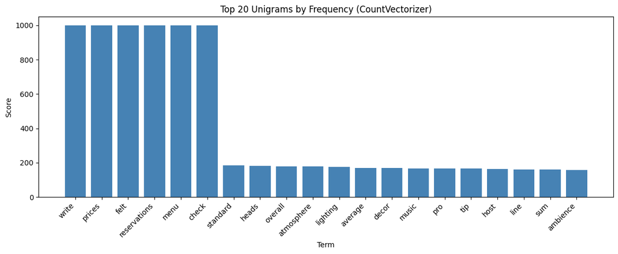

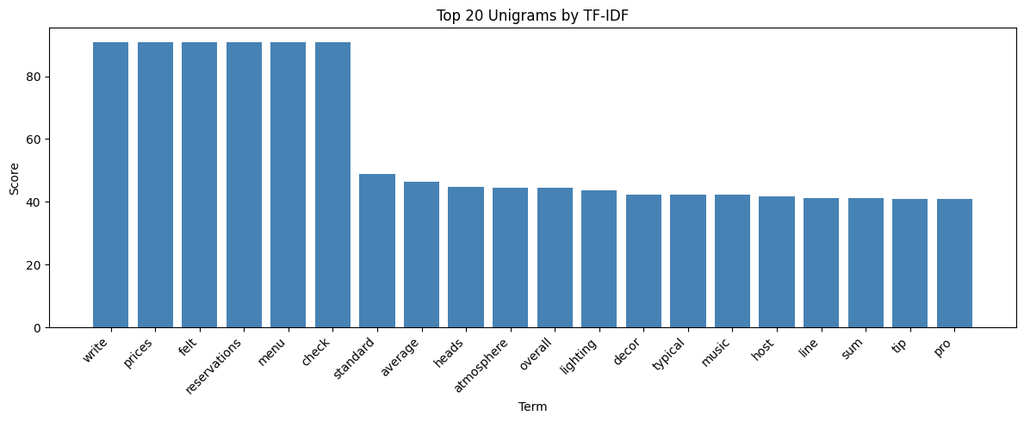

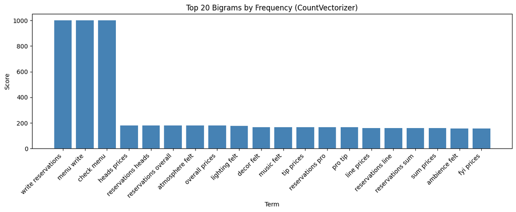

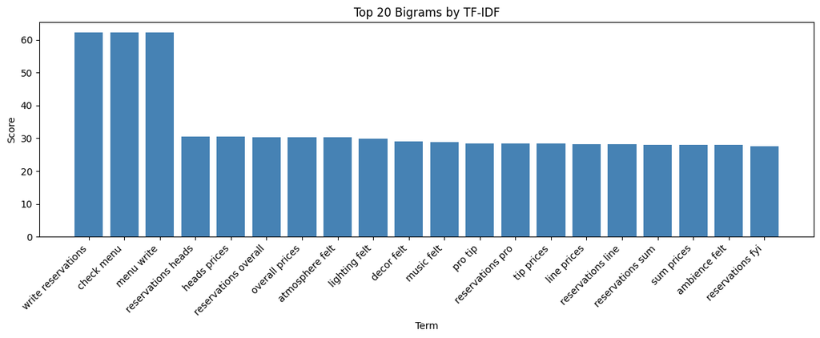

```python
def top_terms(matrix, vectorizer, top_n=20):
    sums = np.asarray(matrix.sum(axis=0)).ravel()
    terms = vectorizer.get_feature_names_out()
    top_indices = sums.argsort()[::-1][:top_n]
    top_terms_list = [(terms[i], sums[i]) for i in top_indices]
    return top_terms_list

def graph_top_terms(term_list, title):
    terms, scores = zip(*term_list)
    plt.figure(figsize=(12, 5))
    plt.bar(terms, scores, color='steelblue')
    plt.xticks(rotation=45, ha='right')
    plt.title(title)
    plt.xlabel("Term")
    plt.ylabel("Score")
    plt.tight_layout()
    plt.show()

top20_unigrams_count = top_terms(uni_matrix, uni_count, top_n=20)
graph_top_terms(top20_unigrams_count, "Top 20 Unigrams by Frequency (CountVectorizer)")

top20_unigrams_tfidf = top_terms(uni_tfidf_matrix, uni_tfidf, top_n=20)
graph_top_terms(top20_unigrams_tfidf, "Top 20 Unigrams by TF-IDF")

top20_bigrams_count = top_terms(X_count_bi, count_bi, top_n=20)
graph_top_terms(top20_bigrams_count, "Top 20 Bigrams by Frequency (CountVectorizer)")

top20_bigrams_tfidf = top_terms(X_tfidf_bi, tfidf_bi, top_n=20)
graph_top_terms(top20_bigrams_tfidf, "Top 20 Bigrams by TF-IDF")
```

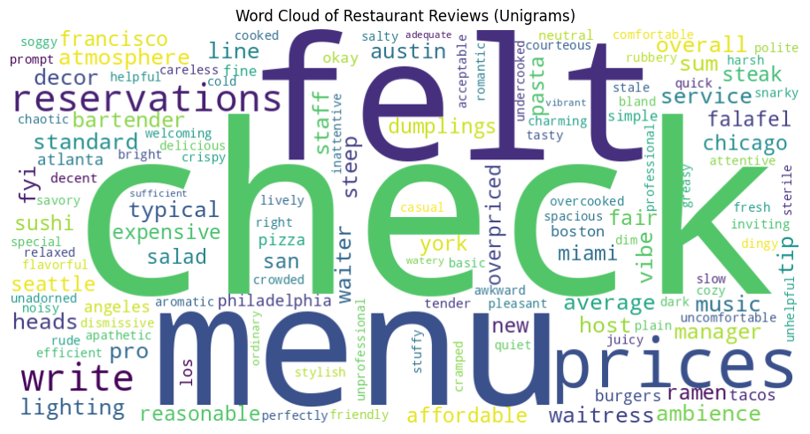

```python
#Unigram Word Cloud
sums = np.asarray(uni_matrix.sum(axis=0)).ravel()
terms = uni_count.get_feature_names_out()

freq_dict = dict(zip(terms, sums))

wordcloud = WordCloud(width=900, height=450, background_color='white').generate_from_frequencies(freq_dict)

plt.figure(figsize=(10, 5))
plt.imshow(wordcloud, interpolation='bilinear')
plt.axis('off')
plt.title("Word Cloud of Restaurant Reviews (Unigrams)")
plt.tight_layout()
plt.show()
```

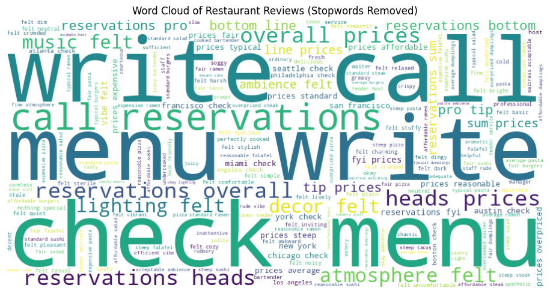

```python
#Bigram Word Cloud
text_for_wc = " ".join([" ".join(doc) for doc in df['tokens']])

wordcloud = WordCloud(width=900, height=450, background_color='white').generate(text_for_wc)

plt.figure(figsize=(10, 5))
plt.imshow(wordcloud, interpolation='bilinear')
plt.axis('off')
plt.title("Word Cloud of Restaurant Reviews (Stopwords Removed)")
plt.tight_layout()
plt.show()
```

Conclusions: The unigram and bigram word clouds reveal that customer reviews focus heavily on pricing, reservations, and the overall dining experience. In the unigram cloud, individual words such as “menu,” “prices,” “check,” and “reservations” appear most prominently, indicating that cost and logistics are common themes in reviews. The bigram cloud provides more context by showing phrases like “menu write,” “check menu,” and “reservations overall,” which could mean that reviewers frequently discuss menu pricing and the reservation process when evaluating restaurants.

### Sentiment Analysis

VADER was used for sentiment analysis on this dataset because it is designed for short opinion-based text like reviews and uses a sentiment lexicon to classify positive and negative language. We used VADER on the text that had not been processed or tokenized so it would retain the original emphasis with relevant punctuation or capitalization.

```
Sentiment Label Counts:
sentiment_label
positive    565
negative    262
neutral     173
Name: count, dtype: int64
```

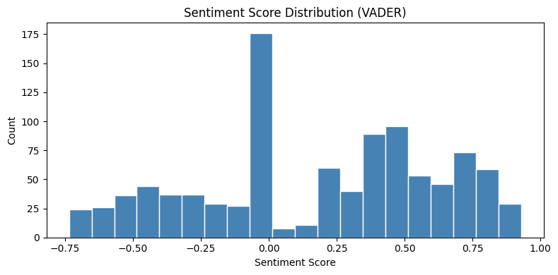

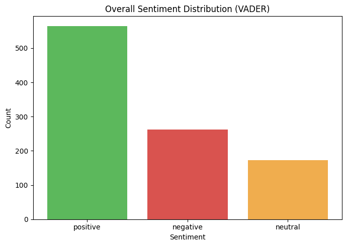

```python
analyzer = SentimentIntensityAnalyzer()

df['sentiment_score'] = df['text'].apply(
    lambda x: analyzer.polarity_scores(str(x))['compound']
)

def label_sentiment(score):
    if score >= 0.01:
        return 'positive'
    elif score <= -0.01:
        return 'negative'
    else:
        return 'neutral'

df['sentiment_label'] = df['sentiment_score'].apply(label_sentiment)

print("Sentiment Label Counts:")
print(df['sentiment_label'].value_counts())

# Sentiment Score Distribution
plt.figure(figsize=(8, 4))
plt.hist(df['sentiment_score'], bins=20, color='steelblue', edgecolor='white')
plt.title("Sentiment Score Distribution (VADER)")
plt.xlabel("Sentiment Score")
plt.ylabel("Count")
plt.tight_layout()
plt.show()

# Sentiment Label Bar Chart
sentiment_counts = df['sentiment_label'].value_counts()
colors = {'positive': '#5cb85c', 'neutral': '#f0ad4e', 'negative': '#d9534f'}

plt.figure(figsize=(7, 5))
plt.bar(sentiment_counts.index,
        sentiment_counts.values,
        color=[colors.get(x, 'steelblue') for x in sentiment_counts.index])
plt.title("Overall Sentiment Distribution (VADER)")
plt.xlabel("Sentiment")
plt.ylabel("Count")
plt.tight_layout()
plt.show()
```

Conclusions: From the distribution chart (-1 to 1 score), most reviews fall on the positive side of the scale (around 0.3–0.8), suggesting that the majority of restaurant reviews express generally positive opinions. There are still a noticeable number of negative scores on the left side, indicating some dissatisfied customers, but these occur less frequently than positive reviews. The cluster around 0 represents reviews with neutral or mixed sentiment.

### LDA Model

Two LDA models were tested to determine the appropriate number of topics for the dataset. A 5-topic model was first created to capture the main, broader themes within the restaurant reviews. A second model with 8 topics was then tested to see if a larger number of topics would separate the themes into more specific categories. Both models were evaluated using coherence and perplexity scores to compare interpretability and model fit.

```python
tokens_lda_sw = [
    [w for w in tokens if w not in stop_words and len(w) > 2
     and w not in ['www', 'com', 'org', 'net', 'http', 'html', 'div',
                   'href', 'br', 'img', 'src', 'foodie', 'local', 'example',
                   'reviews', 'eats', 'bestbites', 'io', 'php', 'htm']]
    for tokens in df['tokens']
]

dictionary = corpora.Dictionary(tokens_lda_sw)
dictionary.filter_extremes(no_below=5, no_above=0.5)
corpus = [dictionary.doc2bow(doc) for doc in tokens_lda_sw]

print("Unique tokens in dictionary:", len(dictionary))

#LDA Model 1 – 5 topics
lda_model1 = LdaModel(corpus=corpus, id2word=dictionary, num_topics=5, passes=10, random_state=42)
print("\n--- LDA Model 1 (5 Topics) ---")
for topic_id in range(5):
    print(f"Topic {topic_id}:", lda_model1.print_topic(topic_id))

#LDA Model 2 – 8 topics
lda_model2 = LdaModel(corpus=corpus, id2word=dictionary, num_topics=8, passes=10, random_state=42)
print("\n--- LDA Model 2 (8 Topics) ---")
for topic_id in range(8):
    print(f"Topic {topic_id}:", lda_model2.print_topic(topic_id))

#Coherence & Perplexity
coherence_model1 = CoherenceModel(model=lda_model1, texts=tokens_lda_sw, dictionary=dictionary, coherence='c_v')
coherence1 = coherence_model1.get_coherence()
perplexity1 = lda_model1.log_perplexity(corpus)
print(f"\nModel 1 (5 topics) — Coherence: {coherence1:.4f} | Log Perplexity: {perplexity1:.4f}")

coherence_model2 = CoherenceModel(model=lda_model2, texts=tokens_lda_sw, dictionary=dictionary, coherence='c_v')
coherence2 = coherence_model2.get_coherence()
perplexity2 = lda_model2.log_perplexity(corpus)
print(f"Model 2 (8 topics) — Coherence: {coherence2:.4f} | Log Perplexity: {perplexity2:.4f}")
```

```
Unique tokens in dictionary: 134

--- LDA Model 1 (5 Topics) ---
Topic 0: 0.114*"line" + 0.114*"bottom" + 0.054*"york" + 0.054*"new" + 0.037*"waiter" + 0.034*"lighting" + 0.033*"austin" + 0.032*"ramen" + 0.029*"undercooked" + 0.022*"sterile"
Topic 1: 0.042*"expensive" + 0.035*"overpriced" + 0.033*"steep" + 0.025*"pro" + 0.025*"tip" + 0.023*"heads" + 0.022*"ambience" + 0.021*"overcooked" + 0.020*"vibe" + 0.019*"service"
Topic 2: 0.041*"fair" + 0.035*"reasonable" + 0.035*"affordable" + 0.021*"ambience" + 0.020*"fyi" + 0.019*"host" + 0.019*"tip" + 0.019*"pro" + 0.018*"heads" + 0.018*"vibe"
Topic 3: 0.053*"steep" + 0.039*"overall" + 0.039*"host" + 0.031*"overpriced" + 0.029*"sterile" + 0.028*"francisco" + 0.027*"san" + 0.026*"atmosphere" + 0.026*"lighting" + 0.025*"seattle"
Topic 4: 0.061*"standard" + 0.058*"average" + 0.050*"typical" + 0.026*"okay" + 0.023*"fine" + 0.021*"atmosphere" + 0.021*"simple" + 0.020*"neutral" + 0.020*"heads" + 0.019*"decent"

--- LDA Model 2 (8 Topics) ---
Topic 0: 0.109*"bottom" + 0.109*"line" + 0.041*"perfectly" + 0.041*"cooked" + 0.032*"lighting" + 0.031*"austin" + 0.026*"undercooked" + 0.025*"waiter" + 0.023*"ramen" + 0.023*"bartender"
Topic 1: 0.054*"tip" + 0.054*"pro" + 0.046*"steep" + 0.037*"bland" + 0.031*"new" + 0.031*"york" + 0.030*"ambience" + 0.029*"expensive" + 0.027*"bottom" + 0.027*"line"
Topic 2: 0.044*"fair" + 0.034*"affordable" + 0.031*"reasonable" + 0.022*"fyi" + 0.021*"tip" + 0.021*"pro" + 0.021*"host" + 0.020*"decor" + 0.020*"ambience" + 0.019*"atmosphere"
Topic 3: 0.051*"steep" + 0.041*"overpriced" + 0.032*"seattle" + 0.030*"heads" + 0.028*"decor" + 0.028*"lighting" + 0.025*"austin" + 0.025*"sum" + 0.024*"pasta" + 0.024*"overall"
Topic 4: 0.081*"average" + 0.039*"standard" + 0.035*"typical" + 0.029*"neutral" + 0.028*"simple" + 0.028*"music" + 0.027*"decent" + 0.025*"heads" + 0.024*"nothing" + 0.024*"special"
Topic 5: 0.129*"pizza" + 0.061*"lighting" + 0.043*"bartender" + 0.042*"heads" + 0.041*"service" + 0.041*"vibe" + 0.036*"miami" + 0.035*"reasonable" + 0.029*"okay" + 0.028*"inviting"
Topic 6: 0.076*"standard" + 0.060*"typical" + 0.033*"average" + 0.029*"bottom" + 0.029*"line" + 0.028*"okay" + 0.026*"fine" + 0.024*"atmosphere" + 0.020*"waiter" + 0.019*"lighting"
Topic 7: 0.044*"expensive" + 0.041*"overpriced" + 0.031*"overall" + 0.029*"waiter" + 0.028*"atmosphere" + 0.026*"unhelpful" + 0.025*"steep" + 0.025*"rude" + 0.025*"sterile" + 0.025*"waitress"

Model 1 (5 topics) — Coherence: 0.2397 | Log Perplexity: -4.6426
Model 2 (8 topics) — Coherence: 0.2259 | Log Perplexity: -4.7212
```

The 5-topic model achieved a slightly higher coherence score (0.2397) compared to the 8-topic model (0.2259), indicating that the topics in the 5-topic model were more interpretable. For the sake of usability for a restaurant owner, we went with the more interpretable option.

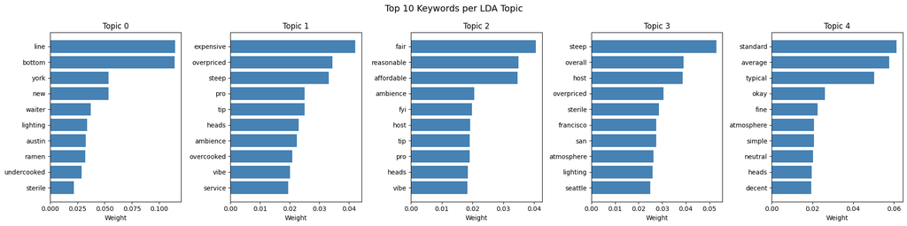

```python
best_model = lda_model1
best_n_topics = 5

fig, axes = plt.subplots(1, best_n_topics, figsize=(20, 5), sharey=False)
for i in range(best_n_topics):
    topic_terms = best_model.show_topic(i, topn=10)
    words, weights = zip(*topic_terms)
    axes[i].barh(words[::-1], weights[::-1], color='steelblue')
    axes[i].set_title(f"Topic {i}")
    axes[i].set_xlabel("Weight")
plt.suptitle("Top 10 Keywords per LDA Topic", fontsize=14)
plt.tight_layout()
plt.show()
```

Topic conclusion: our 5-topic model (lda_model1) produced clear themes related to pricing perceptions (expensive, overpriced, steep, tip), value assessments (affordable, reasonable, fair), general dining experience (average, typical, standard), and service or atmosphere factors (waiter, ambience, lighting, vibe). The visualization of the top keywords shows that many reviews focus on price and overall experience, with additional discussion of service and restaurant atmosphere.

### Analysis

Q1: Which words are most strongly associated with different star ratings?

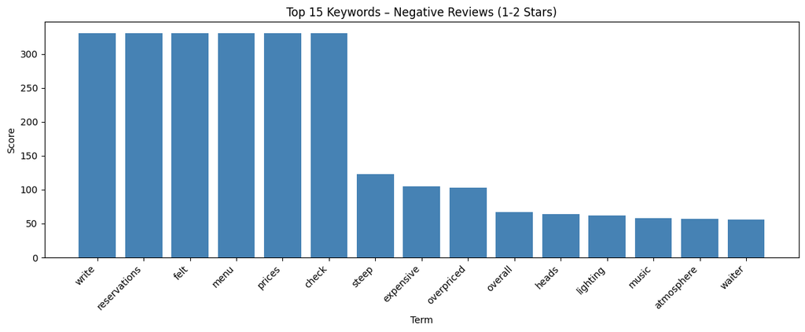

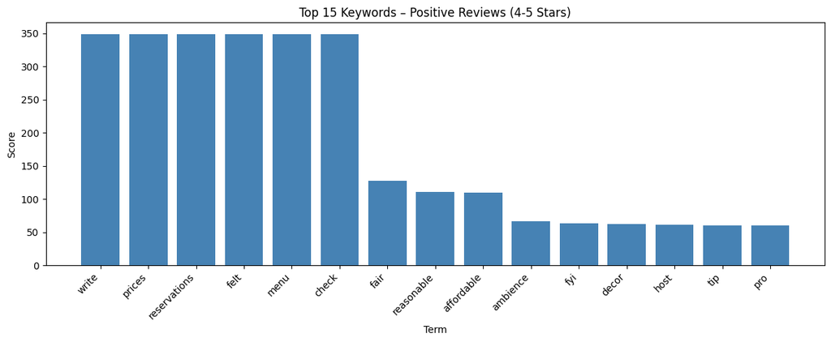

```python
neg_texts = df[df['label'].isin([1, 2])]['clean_text'].tolist()
pos_texts = df[df['label'].isin([4, 5])]['clean_text'].tolist()

vec_neg = CountVectorizer(stop_words='english')
mat_neg = vec_neg.fit_transform(neg_texts)
top_neg = top_terms(mat_neg, vec_neg, top_n=15)

vec_pos = CountVectorizer(stop_words='english')
mat_pos = vec_pos.fit_transform(pos_texts)
top_pos = top_terms(mat_pos, vec_pos, top_n=15)

graph_top_terms(top_neg, "Top 15 Keywords – Negative Reviews (1-2 Stars)")
graph_top_terms(top_pos, "Top 15 Keywords – Positive Reviews (4-5 Stars)")
```

Q1 Conclusion:

Reviews with 4-5 stars (typically positive) focused on words related to fair prices, reservations, service including the front of house hosts, and the overall vibe. Words such as fair, reasonable and affordable were used commonly, as well as ambience, decor and felt. These indicate positive sentiments surrounding pricing, vibe and atmosphere and the service/tipping.

Reviews with 1-2 stars seem to also heavily focus on the reservations, and also steep prices and asepcts of the vibe of a resaurant customers often complain about. Words such as steep, prices, expensive, and overpriced are used often in those reviews, as well as atmosphere, music and lights, probably inidicating dissatisfaction with lighting being too bright or dark and music being too loud.

Q3: How does sentiment (positive vs. negative) vary across star ratings?

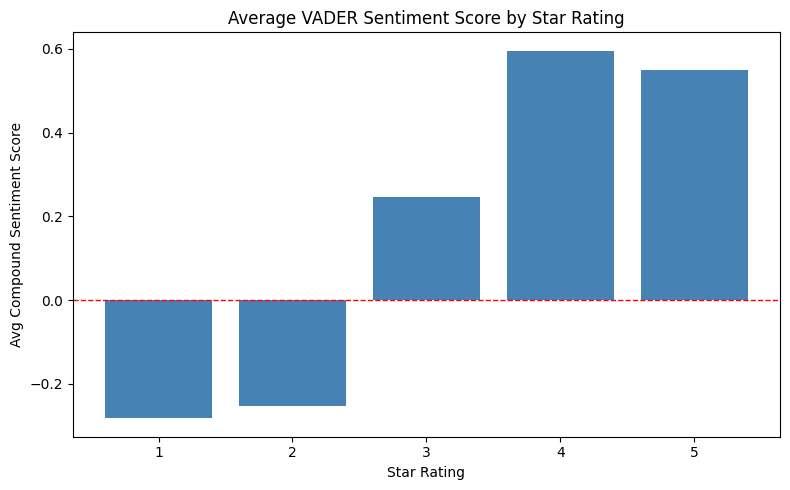

```
Avg Sentiment Score by Rating:
label
1   -0.282017
2   -0.251583
3    0.247601
4    0.595733
5    0.549358
Name: sentiment_score, dtype: float64
```

```python
avg_sentiment = df.groupby('label')['sentiment_score'].mean()

plt.figure(figsize=(8, 5))
plt.bar(avg_sentiment.index.astype(str), avg_sentiment.values, color='steelblue')
plt.axhline(0, color='red', linestyle='--', linewidth=1)
plt.title("Average VADER Sentiment Score by Star Rating")
plt.xlabel("Star Rating")
plt.ylabel("Avg Compound Sentiment Score")
plt.tight_layout()
plt.show()

print("Avg Sentiment Score by Rating:")
print(avg_sentiment)
```

Q3 Conclusion:

Reviews with 1–2 stars show negative average sentiment, while 3-star reviews appear slightly positive but close to neutral, suggesting mixed experiences. In contrast, 4 and 5-star reviews have strongly positive sentiment scores, confirming that customers who leave higher ratings tend to use more positive language in their written reviews.

We thought it was interesting that the average sentiment score was actually higher for 4 star reviews than it was for the 5 star reviews. This may be because they wrote more in their review, but it was interesting to find that out. For owners, it would be good to look at the 4 star reviews, as they might give the most insight into what the best aspects are.

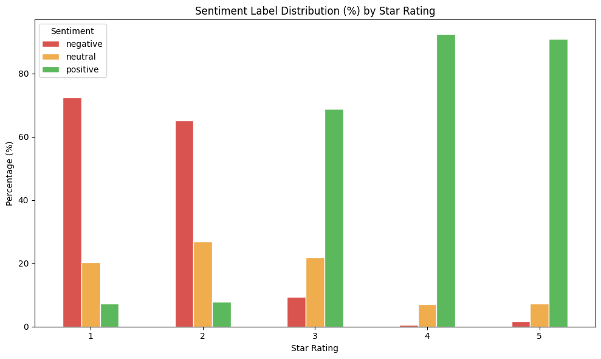

```
sentiment_label   negative    neutral   positive
label
1                72.455090  20.359281   7.185629
2                65.243902  26.829268   7.926829
3                 9.375000  21.875000  68.750000
4                 0.584795   7.017544  92.397661
5                 1.685393   7.303371  91.011236
```

```python
sentiment_cross = pd.crosstab(df['label'], df['sentiment_label'], normalize='index') * 100

sentiment_cross.plot(
    kind='bar',
    figsize=(10, 6),
    color=['#d9534f', '#f0ad4e', '#5cb85c'],
    edgecolor='white'
)
plt.title("Sentiment Label Distribution (%) by Star Rating")
plt.xlabel("Star Rating")
plt.ylabel("Percentage (%)")
plt.xticks(rotation=0)
plt.legend(title="Sentiment")
plt.tight_layout()
plt.show()

print(sentiment_cross)
```

Q3 Conclusion cont.:

The sentiment label distribution supports the pattern seen in the average sentiment scores. 1-2 stars are overall negative, 4-5 stars are overall positive with 3 stars being a combination of positive, neutral, and negative language.

This suggests that mid-range reviews may provide the most useful feedback, as they often include both strengths and areas for improvement. Restaurants could focus on these reviews to better understand what aspects of the experience are working well and what may need improvement.

Q4: Are certain topics more common in high-rated versus low-rated reviews?

(We chose to do this with bigrams to get the best context for the topics)

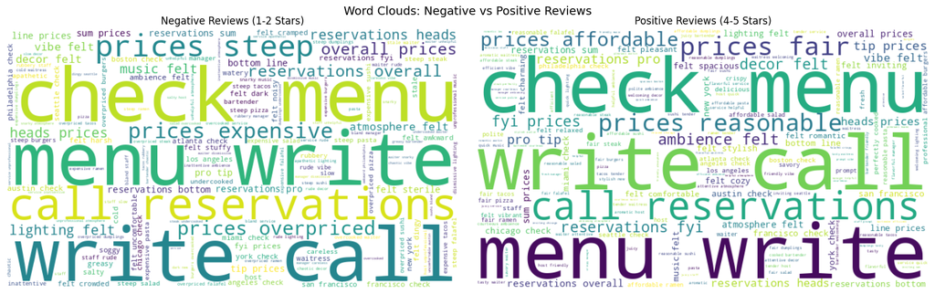

```python
neg_tokens = df[df['label'].isin([1, 2])]['tokens']
pos_tokens = df[df['label'].isin([4, 5])]['tokens']

wc_neg = " ".join([" ".join(doc) for doc in neg_tokens])
wc_pos = " ".join([" ".join(doc) for doc in pos_tokens])

fig, axes = plt.subplots(1, 2, figsize=(16, 5))

wc_neg_obj = WordCloud(width=700, height=400, background_color='white').generate(wc_neg)
axes[0].imshow(wc_neg_obj, interpolation='bilinear')
axes[0].axis('off')
axes[0].set_title("Negative Reviews (1-2 Stars)")

wc_pos_obj = WordCloud(width=700, height=400, background_color='white').generate(wc_pos)
axes[1].imshow(wc_pos_obj, interpolation='bilinear')
axes[1].axis('off')
axes[1].set_title("Positive Reviews (4-5 Stars)")

plt.suptitle("Word Clouds: Negative vs Positive Reviews", fontsize=14)
plt.tight_layout()
plt.show()
```

Q4 Conclusion:

Yes, certain topics appear more frequently in high-rated versus low-rated reviews. In low-rated reviews, words related to pricing concerns and negative experiences appear more often, such as expensive, overpriced, steep, and references to issues with reservations or the dining experience. These reviews also include terms suggesting dissatisfaction with the overall visit.

In contrast, high-rated reviews (4–5 stars) focus more on positive dining experiences, with common words such as affordable, reasonable, delicious, cozy, and vibe. These reviews emphasize positive aspects like food quality, atmosphere, and value.

Overall, negative reviews tend to focus on cost and problems with the experience, while positive reviews highlight quality, comfort, and satisfaction with the meal and environment. This gives restaurants room to see what topics customers are most satisfied and least satisfied with.

### Rating Prediction

In this section, we built several machine learning models to predict restaurant review ratings based on the text of the reviews.

First, we created a binary dataset by removing neutral 3-star reviews and labeling reviews as either positive (4–5 stars) or negative (1–2 stars). The data was then split into training (80%) and testing (20%) sets so that the models could be trained and evaluated on separate data.

```python
df_binary = df[df['label'] != 3].copy()
df_binary['target'] = (df_binary['label'] >= 4).astype(int)

print(f"Binary dataset: {len(df_binary)} reviews")
print(df_binary['target'].value_counts())

X = df_binary['clean_text'].tolist()
y = df_binary['target'].tolist()

X_train, X_test, y_train, y_test = train_test_split(
    X, y, test_size=0.2, random_state=42, stratify=y
)

print(f"\nTrain: {len(X_train)} | Test: {len(X_test)}")
```

```
Binary dataset: 680 reviews
target
1    349
0    331
Name: count, dtype: int64

Train: 544 | Test: 136
```

We then tested multiple text-based modeling approaches:

The first set of models used Bag-of-Words and TF-IDF representations with Naive Bayes classifiers to determine whether simple word presence or word importance could predict review sentiment.

```python
stops = list(stop_words)

def run_model(vectorizer, clf, model_name):
    X_train_vec = vectorizer.fit_transform(X_train)
    X_test_vec  = vectorizer.transform(X_test)

    start = time.time()
    clf.fit(X_train_vec.toarray(), y_train)
    train_time = time.time() - start

    predicted = clf.predict(X_test_vec.toarray())

    print("=" * 50)
    print(model_name)
    print("Number of features:", len(vectorizer.get_feature_names_out()))
    print("Training time (seconds):", round(train_time, 4))
    print("\nPerformance:\n")
    print(metrics.classification_report(y_test, predicted))
    print("Accuracy:", metrics.accuracy_score(y_test, predicted), "\n")

    return metrics.accuracy_score(y_test, predicted), predicted


vec_a = CountVectorizer(
    ngram_range=(1, 1), stop_words=stops,
    max_df=0.9, min_df=1, max_features=None, binary=True
)
clf_a = BernoulliNB()
acc_a, pred_a = run_model(vec_a, clf_a, "Model A: Binary Unigram BOW (BernoulliNB)")


vec_b = CountVectorizer(
    ngram_range=(1, 2), stop_words=stops,
    max_df=0.9, min_df=1, max_features=None, binary=True
)
clf_b = BernoulliNB()
acc_b, pred_b = run_model(vec_b, clf_b, "Model B: Binary Unigrams+Bigrams BOW (BernoulliNB)")
```

```
==================================================
Model A: Binary Unigram BOW (BernoulliNB)
Number of features: 111
Training time (seconds): 0.0054

Performance:

              precision    recall  f1-score   support

           0       1.00      1.00      1.00        66
           1       1.00      1.00      1.00        70

    accuracy                           1.00       136
   macro avg       1.00      1.00      1.00       136
weighted avg       1.00      1.00      1.00       136

Accuracy: 1.0

==================================================
Model B: Binary Unigrams+Bigrams BOW (BernoulliNB)
Number of features: 937
Training time (seconds): 0.0106

Performance:

              precision    recall  f1-score   support

           0       1.00      1.00      1.00        66
           1       1.00      1.00      1.00        70

    accuracy                           1.00       136
   macro avg       1.00      1.00      1.00       136
weighted avg       1.00      1.00      1.00       136

Accuracy: 1.0
```

```python
vec_c = TfidfVectorizer(
    ngram_range=(1, 1), stop_words=stops,
    max_df=0.9, min_df=1, max_features=None
)
clf_c = MultinomialNB()
acc_c, pred_c = run_model(vec_c, clf_c, "Model C: Unigram TF-IDF (MultinomialNB)")


vec_d = TfidfVectorizer(
    ngram_range=(1, 1), stop_words=stops,
    max_df=0.9, min_df=1, max_features=None
)


sent_scores = df_binary['sentiment_score'].tolist()
_, _, sent_train, sent_test = train_test_split(
    X, sent_scores, test_size=0.2, random_state=42, stratify=y
)

X_train_tfidf = vec_d.fit_transform(X_train)
X_test_tfidf  = vec_d.transform(X_test)


min_sent = min(sent_train)
sent_train_mat = csr_matrix((np.array(sent_train) - min_sent + 0.001).reshape(-1, 1))
sent_test_mat  = csr_matrix((np.array(sent_test)  - min_sent + 0.001).reshape(-1, 1))

X_train_d = hstack([X_train_tfidf, sent_train_mat])
X_test_d  = hstack([X_test_tfidf,  sent_test_mat])
```

```
==================================================
Model C: Unigram TF-IDF (MultinomialNB)
Number of features: 111
Training time (seconds): 0.0027

Performance:

              precision    recall  f1-score   support

           0       1.00      1.00      1.00        66
           1       1.00      1.00      1.00        70

    accuracy                           1.00       136
   macro avg       1.00      1.00      1.00       136
weighted avg       1.00      1.00      1.00       136

Accuracy: 1.0
```

In the second stage, we expanded the feature set by combining VADER sentiment scores, LDA topic probabilities, and TF-IDF keywords.

```python
#Use all 5 star ratings as target
X_text = df['clean_text'].tolist()
y_star = df['label'].tolist()

#Feature 1: VADER sentiment score
#Feature 2: Topic probabilities
topic_probs = []
for doc in tokens_lda_sw:
    bow = dictionary.doc2bow(doc)
    topic_dist = dict(lda_model1.get_document_topics(bow, minimum_probability=0))
    row = [topic_dist.get(i, 0) for i in range(5)]
    topic_probs.append(row)

topic_df = pd.DataFrame(topic_probs, columns=[f'topic_{i}' for i in range(5)])

#Feature 3: TF-IDF top 100 keywords
tfidf_feat = TfidfVectorizer(stop_words='english', max_features=100)
tfidf_mat = tfidf_feat.fit_transform(X_text)
tfidf_feat_df = pd.DataFrame(tfidf_mat.toarray(), columns=tfidf_feat.get_feature_names_out())

#Combine all features
feature_df = pd.concat([
    df[['sentiment_score']].reset_index(drop=True),
    topic_df.reset_index(drop=True),
    tfidf_feat_df.reset_index(drop=True)
], axis=1)

print("Feature matrix shape:", feature_df.shape)
print(feature_df.head())
```

```
Feature matrix shape: (1000, 106)
   sentiment_score   topic_0   topic_1   topic_2   topic_3   topic_4  \
0           0.6408  0.020472  0.020393  0.918585  0.020229  0.020321
1           0.6705  0.018311  0.018434  0.925731  0.018981  0.018543
2          -0.6369  0.018387  0.926257  0.018469  0.018447  0.018439
3           0.3182  0.295078  0.018381  0.649541  0.018583  0.018417
4          -0.3818  0.776964  0.017257  0.016859  0.172075  0.016844

   acceptable  affordable  ambience   angeles  ...  unadorned  uncomfortable  \
0         0.0    0.000000  0.000000  0.000000  ...        0.0       0.000000
1         0.0    0.000000  0.000000  0.325536  ...        0.0       0.000000
2         0.0    0.000000  0.299962  0.000000  ...        0.0       0.000000
3         0.0    0.324613  0.000000  0.000000  ...        0.0       0.000000
4         0.0    0.000000  0.000000  0.000000  ...        0.0       0.408387

   undercooked  unprofessional      vibe    waiter  waitress  welcoming  \
0          0.0             0.0  0.000000  0.368875       0.0        0.0
1          0.0             0.0  0.000000  0.000000       0.0        0.0
2          0.0             0.0  0.000000  0.000000       0.0        0.0
3          0.0             0.0  0.000000  0.000000       0.0        0.0
4          0.0             0.0  0.274587  0.000000       0.0        0.0

      write      york
0  0.126400  0.000000
1  0.095805  0.000000
2  0.105626  0.000000
3  0.101466  0.000000
4  0.095615  0.305036

[5 rows x 106 columns]
```

These features were used to train Logistic Regression and Random Forest models to predict the star rating of reviews. Alex and Joe have done Random Forest in other python and BIA classes, which is why it is applied here.

This allowed us to compare how well different types of textual features contribute to predicting review outcomes.

```python
from sklearn.linear_model import LogisticRegression
from sklearn.ensemble import RandomForestClassifier

X_features = feature_df.values
y_target = df['label'].values

X_train, X_test, y_train, y_test = train_test_split(
    X_features, y_target, test_size=0.2, random_state=42, stratify=y_target
)

print(f"Train: {len(X_train)} | Test: {len(X_test)}")

def run_model_v2(X_tr, X_te, clf, model_name):
    start = time.time()
    clf.fit(X_tr, y_train)
    train_time = time.time() - start

    predicted = clf.predict(X_te)

    print("=" * 50)
    print(model_name)
    print("Training time (seconds):", round(train_time, 4))
    print("\nPerformance:\n")
    print(metrics.classification_report(y_test, predicted))
    print("Accuracy:", metrics.accuracy_score(y_test, predicted), "\n")

    return metrics.accuracy_score(y_test, predicted), predicted

#Split features into groups for comparison
sent_idx = 0                        # sentiment score column
topic_idx = slice(1, 6)             # topic probability columns
tfidf_idx = slice(6, feature_df.shape[1])  # TF-IDF columns

#Model A: Sentiment only
acc_a, pred_a = run_model_v2(
    X_train[:, [sent_idx]], X_test[:, [sent_idx]],
    LogisticRegression(max_iter=1000, random_state=42),
    "Model A: Sentiment Score Only (Logistic Regression)"
)

#Model B: Topic probabilities only
acc_b, pred_b = run_model_v2(
    X_train[:, topic_idx], X_test[:, topic_idx],
    LogisticRegression(max_iter=1000, random_state=42),
    "Model B: LDA Topic Probabilities Only (Logistic Regression)"
)

#Model C: TF-IDF keywords only
acc_c, pred_c = run_model_v2(
    X_train[:, tfidf_idx], X_test[:, tfidf_idx],
    LogisticRegression(max_iter=1000, random_state=42),
    "Model C: TF-IDF Keywords Only (Logistic Regression)"
)

#Model D: All features combined
acc_d, pred_d = run_model_v2(
    X_train, X_test,
    LogisticRegression(max_iter=1000, random_state=42),
    "Model D: Sentiment + Topics + TF-IDF Combined (Logistic Regression)"
)

#Model E: All features with Random Forest
acc_e, pred_e = run_model_v2(
    X_train, X_test,
    RandomForestClassifier(n_estimators=100, random_state=42),
    "Model E: Sentiment + Topics + TF-IDF Combined (Random Forest)"
)
```

```
Train: 800 | Test: 200
==================================================
Model A: Sentiment Score Only (Logistic Regression)
Training time (seconds): 0.0126

Performance:

              precision    recall  f1-score   support

           1       0.48      0.61      0.53        33
           2       1.00      0.15      0.26        33
           3       0.49      0.78      0.60        64
           4       0.38      0.56      0.45        34
           5       0.00      0.00      0.00        36

    accuracy                           0.47       200
   macro avg       0.47      0.42      0.37       200
weighted avg       0.46      0.47      0.40       200

Accuracy: 0.47

==================================================
Model B: LDA Topic Probabilities Only (Logistic Regression)
Training time (seconds): 0.0131

Performance:

              precision    recall  f1-score   support

           1       0.49      0.64      0.55        33
           2       0.48      0.33      0.39        33
           3       1.00      1.00      1.00        64
           4       0.48      0.76      0.59        34
           5       0.50      0.22      0.31        36

    accuracy                           0.65       200
   macro avg       0.59      0.59      0.57       200
weighted avg       0.65      0.65      0.63       200

Accuracy: 0.65
```

[output cut: 25 more lines]

```
Performance:

              precision    recall  f1-score   support

           1       0.54      0.61      0.57        33
           2       0.55      0.48      0.52        33
           3       1.00      1.00      1.00        64
           4       0.47      0.50      0.49        34
           5       0.50      0.47      0.49        36

    accuracy                           0.67       200
   macro avg       0.61      0.61      0.61       200
weighted avg       0.67      0.67      0.67       200

Accuracy: 0.67
```

```
==================================================
Model E: Sentiment + Topics + TF-IDF Combined (Random Forest)
Training time (seconds): 0.4097

Performance:

              precision    recall  f1-score   support

           1       0.51      0.58      0.54        33
           2       0.52      0.45      0.48        33
           3       1.00      1.00      1.00        64
           4       0.55      0.50      0.52        34
           5       0.56      0.61      0.59        36

    accuracy                           0.69       200
   macro avg       0.63      0.63      0.63       200
weighted avg       0.68      0.69      0.68       200

Accuracy: 0.685
```

Conclusion: Our random forest model that was Sentiment + Topics + TF-IDF Combined gave the highest accuracy of all models. It also took the longest to train, which if used on a much larger scale could raise cost considerations. Sentiment Score Only (Logistic Regression) performed the worst with .47 accuracy took one of the shortest ammount of time to train.